## Integrantes

Iván Fernandez París

Javier Fraile Iglesias

# Apartado 1

```python
from ClasificadorKNN import ClasificadorKNN
from Datos import Datos
import EstrategiaParticionado

import matplotlib.pyplot as plt
import pandas as pd
import numpy as np
```

```python
# Datos
dataset_wdbc= Datos('./wdbc.csv')
dataset_prima = Datos('./pima-indians-diabetes.csv')

estrategia = EstrategiaParticionado.ValidacionSimple(numeroEjec=20, propTest=30)

# Classifiers
knn_1_classifier = ClasificadorKNN(K=1)
knn_1_classifier_normalized = ClasificadorKNN(normalizar=True, K=1)
knn_3_classifier = ClasificadorKNN(K=3)
knn_3_classifier_normalized = ClasificadorKNN(normalizar=True, K=3)
knn_5_classifier = ClasificadorKNN(K=5)
knn_5_classifier_normalized = ClasificadorKNN(normalizar=True, K=5)
knn_11_classifier = ClasificadorKNN(K=11)
knn_11_classifier_normalized = ClasificadorKNN(normalizar=True, K=11)
knn_21_classifier = ClasificadorKNN(K=21)
knn_21_classifier_normalized = ClasificadorKNN(normalizar=True, K=21)
```

```python
# Predictions wdbc

erroresknn_1 = knn_1_classifier.validacion(estrategia, dataset_wdbc)
erroresknn_1_n = knn_1_classifier_normalized.validacion(estrategia, dataset_wdbc)


erroresknn_3 = knn_3_classifier.validacion(estrategia, dataset_wdbc)
erroresknn_3_n = knn_3_classifier_normalized.validacion(estrategia, dataset_wdbc)


erroresknn_5 = knn_5_classifier.validacion(estrategia, dataset_wdbc)
erroresknn_5_n = knn_5_classifier_normalized.validacion(estrategia, dataset_wdbc)


erroresknn_11 = knn_11_classifier.validacion(estrategia, dataset_wdbc)
erroresknn_11_n = knn_11_classifier_normalized.validacion(estrategia, dataset_wdbc)


erroresknn_21 = knn_21_classifier.validacion(estrategia, dataset_wdbc)
erroresknn_21_n = knn_21_classifier_normalized.validacion(estrategia, dataset_wdbc)

print("1", erroresknn_1)
print("1n", erroresknn_1_n)

print("3", erroresknn_3)
print("3n", erroresknn_3_n)

print("5", erroresknn_5)
print("5n", erroresknn_5_n)

print("11", erroresknn_11)
print("11n", erroresknn_11_n)

print("21", erroresknn_21)
print("21n", erroresknn_21_n)
```

```
1 (0.08450292397660818, 0.0228351153955198)
1n (0.0304093567251462, 0.012210884805743333)
3 (0.07485380116959064, 0.01710963606821964)
3n (0.029239766081871343, 0.014794281451080138)
5 (0.07076023391812866, 0.016837637484079494)
5n (0.0304093567251462, 0.01118779325713976)
11 (0.07426900584795322, 0.017650746517879026)
11n (0.031286549707602335, 0.015502591978726972)
21 (0.07894736842105263, 0.0196146313815771)
21n (0.03859649122807018, 0.018985594246488803)
```

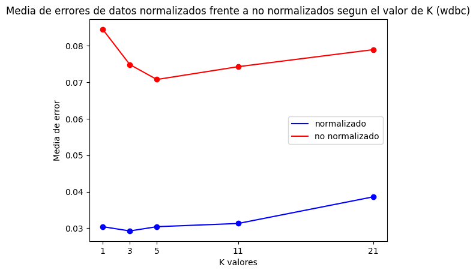

```python
# Plot
non_normalized = [
    erroresknn_1[0], erroresknn_3[0], erroresknn_5[0], erroresknn_11[0], erroresknn_21[0]]

normalized = [
    erroresknn_1_n[0], erroresknn_3_n[0], erroresknn_5_n[0], erroresknn_11_n[0], erroresknn_21_n[0]]

X = [1, 3, 5, 11, 21]

plt.scatter(X, normalized, color="blue")
plt.plot(X, normalized, color="blue", label="normalizado")
plt.scatter(X, non_normalized, color="red")
plt.plot(X, non_normalized, color="red", label="no normalizado")

plt.xlabel("K valores")
plt.ylabel("Media de error")

plt.legend()

plt.xticks(X)
plt.title("Media de errores de datos normalizados frente a no normalizados segun el valor de K (wdbc)")

plt.show()
```

```python
# Predictions pima-indian-diabetes

erroresknn_1 = knn_1_classifier.validacion(estrategia, dataset_prima)
erroresknn_1_n = knn_1_classifier_normalized.validacion(estrategia, dataset_prima)


erroresknn_3 = knn_3_classifier.validacion(estrategia, dataset_prima)
erroresknn_3_n = knn_3_classifier_normalized.validacion(estrategia, dataset_prima)


erroresknn_5 = knn_5_classifier.validacion(estrategia, dataset_prima)
erroresknn_5_n = knn_5_classifier_normalized.validacion(estrategia, dataset_prima)


erroresknn_11 = knn_11_classifier.validacion(estrategia, dataset_prima)
erroresknn_11_n = knn_11_classifier_normalized.validacion(estrategia, dataset_prima)


erroresknn_21 = knn_21_classifier.validacion(estrategia, dataset_prima)
erroresknn_21_n = knn_21_classifier_normalized.validacion(estrategia, dataset_prima)

print("1", erroresknn_1)
print("1n", erroresknn_1_n)

print("3", erroresknn_3)
print("3n", erroresknn_3_n)

print("5", erroresknn_5)
print("5n", erroresknn_5_n)

print("11", erroresknn_11)
print("11n", erroresknn_11_n)

print("21", erroresknn_21)
print("21n", erroresknn_21_n)
```

```
1 (0.33245614035087717, 0.03073793468288776)
1n (0.10380116959064327, 0.022865048379558304)
3 (0.319298245614035, 0.027014758976493792)
3n (0.09239766081871345, 0.017406872591973353)
5 (0.29678362573099415, 0.02218178839184816)
5n (0.1070175438596491, 0.015372443775549607)
11 (0.28567251461988297, 0.02700684580986441)
11n (0.11374269005847955, 0.02442702028763824)
21 (0.28245614035087724, 0.026289785722794175)
21n (0.13421052631578947, 0.029788706804934627)
```

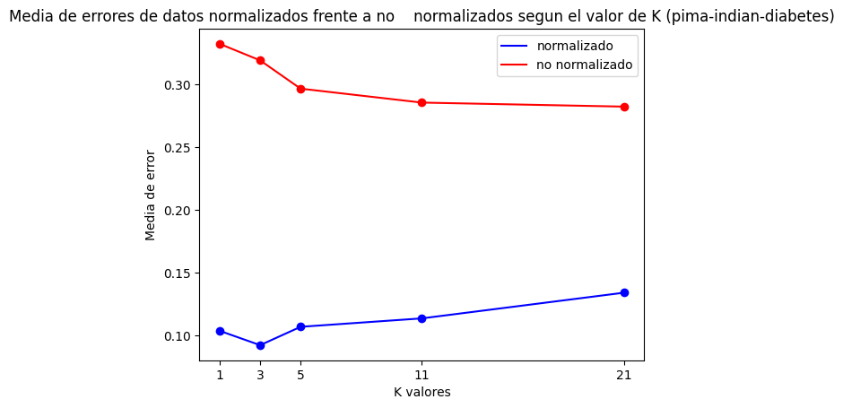

```python
# Plot
non_normalized = [
    erroresknn_1[0], erroresknn_3[0], erroresknn_5[0], erroresknn_11[0], erroresknn_21[0]]

normalized = [
    erroresknn_1_n[0], erroresknn_3_n[0], erroresknn_5_n[0], erroresknn_11_n[0], erroresknn_21_n[0]]

X = [1, 3, 5, 11, 21]

plt.scatter(X, normalized, color="blue")
plt.plot(X, normalized, color="blue", label="normalizado")
plt.scatter(X, non_normalized, color="red")
plt.plot(X, non_normalized, color="red", label="no normalizado")

plt.xlabel("K valores")
plt.ylabel("Media de error")

plt.legend()

plt.xticks(X)
plt.title("Media de errores de datos normalizados frente a no\
    normalizados segun el valor de K (pima-indian-diabetes)")

plt.show()
```

## Justificacion del rendimiento de KNN

EL inconveniente de KNN viene cuando las variables no se encuentran normalizadas, esto sucede por ejemplo si tenemos un atributo que se muve en el (0, 1), y otro que se mueve en rangos (0, 1000). Cuando tenemos estos datos, la segunda variable va a influir mucho mas en el calculo de la distancia euclidea, y consecuentemente en la decion del modelo. A este suceso se le conoce como la maldicion de la dimensionalidad

Es por eso que se aplica una normalizacion de las varibles, para que los rangos por los que se mueven los valores sean parecidos.

En cuanto a nuestros ejemplos, se observa claramente que cuando los atributos no estan normalizados, el rendimiento cae, precisamente por lo que hemos comentado. Con que haya un atributo que se mueva en los intervalors (300-500 por ejemplo), ya esta influyendo mucho mas que el resto (si se mueve de 0 a 1 por ejemplo), y con lo cual los errores aumentan.

## Analizar el impacto de K

Se puede observar que con K = 1, no es un caso muy optimo, ya que tan solo un valor, no va a determinar que la mayoria de los valores cercanos sean iguales a ese K predicho. Igual ese K predice 1, pero los otros 2 K siguientes mas cercanos son de calse 2. Esto se suele llamar sobreajuste de los datos

A medida que aumentamos la K (3, 5, ...) es cuando observamos un menor error, ya que la muestra es lo suficientemente pequeña para no sobreajustar los datos, pero a su vez no demasiado grande para suavizar los datos.

# Apartado 2

```python
from ClusteringKMeans import ClusteringKMeans

# Database
dataset_iris = Datos('./iris.csv')

# Classifiers
km_1_classifier = ClusteringKMeans(K=1)
km_2_classifier = ClusteringKMeans(K=2)
km_3_classifier = ClusteringKMeans(K=3)
km_4_classifier = ClusteringKMeans(K=4)
km_5_classifier = ClusteringKMeans(K=5)
```

## K = 3

```python
# Funcion que devuelve tantos diccionarios como cluster haya con el numero
# de ocurrencias de cada clase en cada cluster
km_3_clusters = km_3_classifier.predict(dataset_iris.datos)
print("3", km_3_clusters)
```

```
3 [{2.0: 2, 3.0: 36}, {2.0: 48, 3.0: 14}, {1.0: 50}]
```

Como se puede observar, hay 3 tipos de flores en nuestro dataset, que tas haber sido normalizadas, quedan con los valores (1.0, 2.0, 3.0).

## Matriz de Confusion

Para la matriz de confusion, lo que hemos realizado, es:

- Quedarnos de cada cluster con la clase mayoritaria. De esta manera sabemos para cada cluster, la clase predicha.
- Guardamos en una tupla por cada centroide dentro del cluster, el valor predicho (que viene dado por el punto 1, y el valor que realmente tiene en el dataset)
- Guardamos todos los valores predichos y todos los valores reales de cada cluster en dos listas e imprimimos la matriz de confusion.

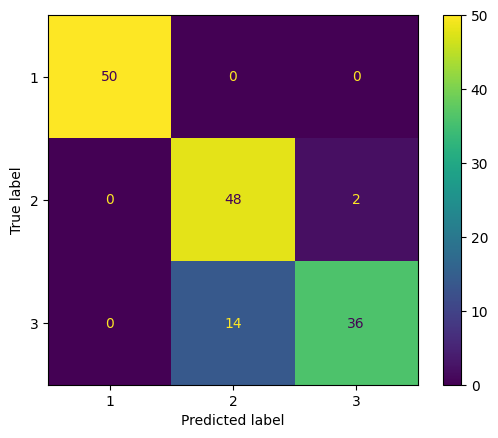

```python
km_3_classifier.get_confusion_matrix()
```

## Para otros valores de K

```python
# Numero de ocurrencias de ocurrencias de cada clase en cada cluster para K clusters
km_1_clusters = km_1_classifier.predict(dataset_iris.datos)
km_2_clusters = km_2_classifier.predict(dataset_iris.datos)
km_4_clusters = km_4_classifier.predict(dataset_iris.datos)
km_5_clusters = km_5_classifier.predict(dataset_iris.datos)

print("1", km_1_clusters)
print("2", km_2_clusters)
print("3", km_3_clusters)
print("4", km_4_clusters)
print("5", km_5_clusters)
```

```
1 [{1.0: 50, 2.0: 50, 3.0: 50}]
2 [{2.0: 47, 3.0: 50}, {1.0: 50, 2.0: 3}]
3 [{2.0: 2, 3.0: 36}, {2.0: 48, 3.0: 14}, {1.0: 50}]
4 [{1.0: 50}, {3.0: 32}, {2.0: 26, 3.0: 1}, {2.0: 24, 3.0: 17}]
5 [{3.0: 24}, {2.0: 27, 3.0: 1}, {1.0: 50}, {3.0: 12}, {2.0: 23, 3.0: 13}]
```

Para K=1, realmente no tiene sentido, porque un solo cluster implica tener todos los valores dentro del mismo conjunto y con lo cual no predecir realmente nada ya que tenemos 3 clases en este caso. Tenemos un problema de sobreajuste.

Para K=2, ya se un poco la tendencia, ya que el grupo 1 lo consigue aislar, pero pasa un poco como en el anterior ejemplo, que teniendo 3 clases, nunca se va a poder dividir entre 3.

Para K=3, deberia ser el caso ideal como hemos mencionado anteriormente, ya que nuestro dataset tiene 3 clases, sin embargo, se ve que se sigue confundiendo con la clase 2 y 3, esto se debe probablemente, a que estos conjunto se encuentran muy cercanos en el espacio.

Para K=4 y K=5, pasan cosas parecidas, y es que consigue separar incluso con el 100% de aciertos en un cluster el grupo 3, pero hay unos puntos de la clase 2 y 3 que estan muy juntos y los caba agrupando mal

## Normalizando los datos

```python
# Funciones auxiliares para normalizar
def calcularMediasDesv(datos):
    mean_desv = []
    attr_cont = 0

    # Para cada columna (menos la clase)
    for attr in datos.columns[:-1]:
        # Se guarda la media y la desviacion tipica
        mean_desv.append((np.mean(datos[attr]), np.std(datos[attr])))
        attr_cont += 1

    return mean_desv

def normalizarDatos(datos):

    data = pd.DataFrame(datos)
    # Se llama a calcular las medias
    means_desv = calcularMediasDesv(data)

    # Se recorre al mismo tiempo los dos arrays (columnas, y media_desviacion),
    # y se aplica la formula d enormalizacion a todos los datos de la columna
    for attr, mean_desv in zip(data.columns[:-1], means_desv):
        data[attr] = [(value - mean_desv[0]) / mean_desv[1]
                        for value in data[attr]]

    return data.to_numpy()
```

```python
# Pruebas para datos normalizados

km_1_clusters_n = km_1_classifier.predict(normalizarDatos(dataset_iris.datos))
km_2_clusters_n = km_2_classifier.predict(normalizarDatos(dataset_iris.datos))
km_3_clusters_n = km_3_classifier.predict(normalizarDatos(dataset_iris.datos))
km_4_clusters_n = km_4_classifier.predict(normalizarDatos(dataset_iris.datos))
km_5_clusters_n = km_5_classifier.predict(normalizarDatos(dataset_iris.datos))

print("1n", km_1_clusters_n)
print("2n", km_2_clusters_n)
print("3n", km_3_clusters_n)
print("4n", km_4_clusters_n)
print("5n", km_5_clusters_n)
```

```
1n [{1.0: 50, 2.0: 50, 3.0: 50}]
2n [{2.0: 50, 3.0: 50}, {1.0: 50}]
3n [{2.0: 39, 3.0: 17}, {2.0: 11, 3.0: 33}, {1.0: 50}]
4n [{1.0: 49}, {2.0: 2, 3.0: 27}, {1.0: 1, 2.0: 19, 3.0: 2}, {2.0: 29, 3.0: 21}]
5n [{1.0: 15}, {1.0: 35}, {2.0: 22, 3.0: 3}, {3.0: 27}, {2.0: 28, 3.0: 20}]
```

Pero normalizar creemos que no es una buena solucion, porque si lo que buscamos son clusters de puntos esparcidos en el espacio y los normalizamos, lo que estamos haciendo es acercarlos más entre ellos, y eso puede empeorar el rendimiento del algoritmo

# Apartado 3

## KNN

```python
from sklearn.model_selection import train_test_split
from sklearn.metrics import accuracy_score
from sklearn.neighbors import KNeighborsClassifier
```

```python
# Data
df_wdbc = pd.DataFrame(dataset_wdbc.datos)
df_wdbc_n = pd.DataFrame(normalizarDatos(dataset_wdbc.datos))

df_prima = pd.DataFrame(dataset_prima.datos)
df_prima_n = pd.DataFrame(normalizarDatos(dataset_prima.datos))


X_wdbc = df_wdbc.iloc[:, :-1]
y_wdbc = df_wdbc.iloc[:, -1]

X_prima = df_prima.iloc[:, :-1]
y_prima = df_prima.iloc[:, -1]

X_wdbc_n = df_wdbc_n.iloc[:, :-1]
y_wdbc_n = df_wdbc_n.iloc[:, -1]

X_prima_n = df_prima_n.iloc[:, :-1]
y_prima_n = df_prima_n.iloc[:, -1]

# Classifiers
knn_1_classifier = KNeighborsClassifier(n_neighbors=1)
knn_3_classifier = KNeighborsClassifier(n_neighbors=3)
knn_5_classifier = KNeighborsClassifier(n_neighbors=5)
knn_11_classifier = KNeighborsClassifier(n_neighbors=11)
knn_21_classifier = KNeighborsClassifier(n_neighbors=21)
```

```python
def predictions(classifier: KNeighborsClassifier, X, y, n_iters):
    errores = []

    for _ in range(n_iters):
        X_train, X_test, y_train, y_test = train_test_split(X, y, test_size=0.3)
        classifier.fit(X_train, y_train)
        y_pred = classifier.predict(X_test)
        errores.append(1 - accuracy_score(y_test, y_pred))

    return np.mean(errores), np.std(errores)
```

```python
# Predictions wdbc
erroresknn_1 = predictions(knn_1_classifier, X_wdbc, y_wdbc, 20)
print("1", erroresknn_1)
erroresknn_1_n = predictions(knn_1_classifier, X_wdbc_n, y_wdbc_n, 20)
print("1n", erroresknn_1_n)

erroresknn_3 = predictions(knn_3_classifier, X_wdbc, y_wdbc, 20)
print("3", erroresknn_3)
erroresknn_3_n = predictions(knn_3_classifier, X_wdbc_n, y_wdbc_n, 20)
print("3n", erroresknn_3_n)

erroresknn_5 = predictions(knn_5_classifier, X_wdbc, y_wdbc, 20)
print("5", erroresknn_5)
erroresknn_5_n = predictions(knn_5_classifier, X_wdbc_n, y_wdbc_n, 20)
print("5n", erroresknn_5_n)

erroresknn_11 = predictions(knn_11_classifier, X_wdbc, y_wdbc, 20)
print("11", erroresknn_11)
erroresknn_11_n = predictions(knn_11_classifier, X_wdbc_n, y_wdbc_n, 20)
print("11n", erroresknn_11_n)

erroresknn_21 = predictions(knn_21_classifier, X_wdbc, y_wdbc, 20)
print("21", erroresknn_21)
erroresknn_21_n = predictions(knn_21_classifier, X_wdbc_n, y_wdbc_n, 20)
print("21n", erroresknn_21_n)
```

```
1 (0.09064327485380116, 0.01952726065153684)
1n (0.04795321637426904, 0.014276673234776261)
3 (0.0751461988304094, 0.01572164334359072)
3n (0.03157894736842109, 0.012731895355015935)
5 (0.06988304093567255, 0.014963791323887705)
5n (0.03245614035087722, 0.01339615343737464)
11 (0.06608187134502926, 0.01457302432090891)
11n (0.03830409356725149, 0.013396153437374617)
21 (0.08187134502923979, 0.025084924666113704)
21n (0.0450292397660819, 0.013601992221769598)
```

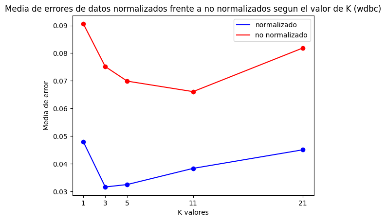

```python
# Plot
non_normalized = [
    erroresknn_1[0], erroresknn_3[0], erroresknn_5[0], erroresknn_11[0], erroresknn_21[0]]

normalized = [
    erroresknn_1_n[0], erroresknn_3_n[0], erroresknn_5_n[0], erroresknn_11_n[0], erroresknn_21_n[0]]

X = [1, 3, 5, 11, 21]

plt.scatter(X, normalized, color="blue")
plt.plot(X, normalized, color="blue", label="normalizado")
plt.scatter(X, non_normalized, color="red")
plt.plot(X, non_normalized, color="red", label="no normalizado")

plt.xlabel("K valores")
plt.ylabel("Media de error")

plt.legend()

plt.xticks(X)
plt.title("Media de errores de datos normalizados frente a no normalizados segun el valor de K (wdbc)")

plt.show()
```

```python
# Predictions wdbc
erroresknn_1 = predictions(knn_1_classifier, X_prima, y_prima, 20)
print("1", erroresknn_1)
erroresknn_1_n = predictions(knn_1_classifier, X_prima_n, y_prima_n, 20)
print("1n", erroresknn_1_n)

erroresknn_3 = predictions(knn_3_classifier, X_prima, y_prima, 20)
print("3", erroresknn_3)
erroresknn_3_n = predictions(knn_3_classifier, X_prima_n, y_prima_n, 20)
print("3n", erroresknn_3_n)

erroresknn_5 = predictions(knn_5_classifier, X_prima, y_prima, 20)
print("5", erroresknn_5)
erroresknn_5_n = predictions(knn_5_classifier, X_prima_n, y_prima_n, 20)
print("5n", erroresknn_5_n)

erroresknn_11 = predictions(knn_11_classifier, X_prima, y_prima, 20)
print("11", erroresknn_11)
erroresknn_11_n = predictions(knn_11_classifier, X_prima_n, y_prima_n, 20)
print("11n", erroresknn_11_n)

erroresknn_21 = predictions(knn_21_classifier, X_prima, y_prima, 20)
print("21", erroresknn_21)
erroresknn_21_n = predictions(knn_21_classifier, X_prima_n, y_prima_n, 20)
print("21n", erroresknn_21_n)
```

```
1 (0.325108225108225, 0.0257166177320851)
1n (0.2950216450216451, 0.02468956071451468)
3 (0.30454545454545456, 0.020038895107808038)
3n (0.27294372294372293, 0.02985051743359552)
5 (0.2813852813852814, 0.024830528830649318)
5n (0.27056277056277056, 0.025037218598997837)
11 (0.2655844155844156, 0.027490881768759346)
11n (0.2612554112554113, 0.022127734316921426)
21 (0.26450216450216446, 0.022779778557442187)
21n (0.25324675324675316, 0.019384080672933426)
```

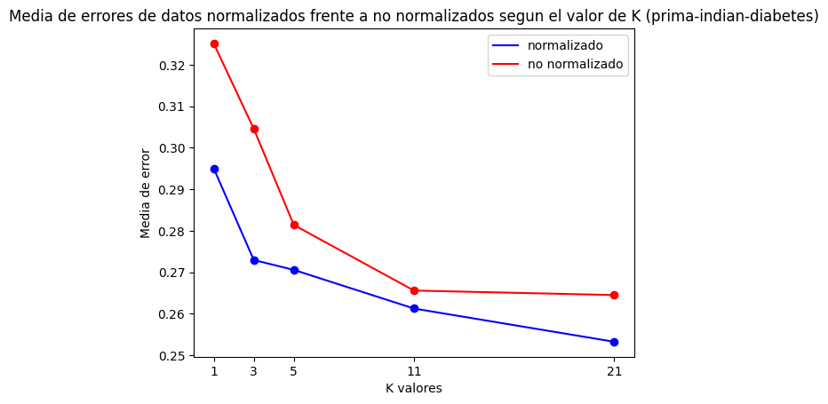

```python
# Plot
non_normalized = [
    erroresknn_1[0], erroresknn_3[0], erroresknn_5[0], erroresknn_11[0], erroresknn_21[0]]

normalized = [
    erroresknn_1_n[0], erroresknn_3_n[0], erroresknn_5_n[0], erroresknn_11_n[0], erroresknn_21_n[0]]

X = [1, 3, 5, 11, 21]

plt.scatter(X, normalized, color="blue")
plt.plot(X, normalized, color="blue", label="normalizado")
plt.scatter(X, non_normalized, color="red")
plt.plot(X, non_normalized, color="red", label="no normalizado")

plt.xlabel("K valores")
plt.ylabel("Media de error")

plt.legend()


plt.xticks(X)
plt.title("Media de errores de datos normalizados frente a no normalizados segun el valor de K (prima-indian-diabetes)")

plt.show()
```

# Analizar resultados

En comparacion con la implementacion propia, en cuanto a el dataset WDBC, si que son bastante parecidos los resultados, dando unos errores en torno al 0.03 y 0.04 cuando los datos estan normalizados, y de 0.07 - 0.08 cuando no se encuentran normlizados, siendo las K intermedias las que menos errores tienen.

Para el dataset prima-indian-diabetes, los errores en general son mas altos, pero en este caso la implementacion propia da mejores resultados de error (en torno al 0.10,0.15) para datos normalizados, mientras que SKL da errores de hasta el 0.3. Cuando el dataset no se encuentra normalizado, si que coincide que los errores rondan el 0.30 de fallos.

## KMeans

```python
from sklearn.cluster import KMeans
from sklearn import metrics
from collections import Counter
```

```python
# Data
df_iris = pd.read_csv("./iris.csv")

X_iris = df_iris.iloc[:, :-1]
y_iris = df_iris.iloc[:, -1]

# Classifiers fits
km_1_classifier = KMeans(n_clusters=1, init='random', max_iter=10000, tol=0).fit(X_iris)
km_2_classifier = KMeans(n_clusters=2, init='random', max_iter=10000, tol=0).fit(X_iris)
km_3_classifier = KMeans(n_clusters=3, init='random', max_iter=10000, tol=0).fit(X_iris)
km_4_classifier = KMeans(n_clusters=4, init='random', max_iter=10000, tol=0).fit(X_iris)
km_5_classifier = KMeans(n_clusters=5, init='random', max_iter=10000, tol=0).fit(X_iris)
```

```python
# Esta funcion se enctarga de devolver K clusters, con la etiqueta correspondiente a cada uno
# de los elementos dentro de un cluster
def get_predicted_cluster_labels(predictions, k):
    clusters = [[] for _ in range(k)]

    # Se itera entre todos los elementos predichos, los cuales van en orden
    i = 0 # Indice
    for pred in predictions:
        # Mete en el cluster correspondiente la label actual de esa clase
        clusters[pred].append(y_iris[i])
        i+=1

    return clusters


# Esta segunda funcion se encarga de contar los elementos de cada cluster, para asi obtener el
# mas repetedio o predicho en cada cluster
def get_clusters_count_labels(clusters):
    # Se itera los clusters y se obtiene en forma de diccionario
    predictions = []
    for cluster in clusters:
        predictions += [dict(Counter(cluster))]

    return predictions

# Esta otra funcion, lo que hace es guardar la clase actual con la clase predicha por cada elemento
# de cada cluster
def set_actual_and_predicted_pair(clusters):
    classes = [[] for _ in range(len(clusters))]

    cluster_idx = 0
    for cluster in clusters:
        # Se obtiene la prediccion de ese cluster
        pred_class = Counter(cluster).most_common(1)[0][0]
        # Se iteran entre los elementos para guardar el par (actual, predicho)
        for actual_class in cluster:
            classes[cluster_idx].append((pred_class, actual_class))
        cluster_idx += 1

    return classes

# Finalmente, la funcion que va a imprimir la matriz de confusion pasando las dos listas
# con las clases predichas y las actuales, para ver las diferencias

def get_confusion_matrix(clusters):
    predicts = []
    actuals = []

    # Se guardan en esas dos listas todas las predicciones y los actuales
    for cluster in clusters:
        for pair in cluster:
            predicts.append(pair[0])
            actuals.append(pair[1])

    # Se dibuja la matriz de confusion
    confusion_matrix = metrics.confusion_matrix(actuals, predicts)

    cm_display = metrics.ConfusionMatrixDisplay(
        confusion_matrix=confusion_matrix, display_labels=[1, 2, 3])

    cm_display.plot()
    plt.show()
```

# K = 3

```
[{'Iris-versicolor': 48, 'Iris-virginica': 14}, {'Iris-versicolor': 2, 'Iris-virginica': 36}, {'Iris-setosa': 50}]
```

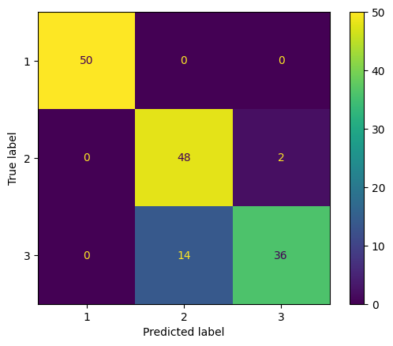

```python
clusters = get_predicted_cluster_labels(km_3_classifier.predict(X_iris), 3)
print(get_clusters_count_labels(clusters))

get_confusion_matrix(set_actual_and_predicted_pair(clusters))
```

Como se puede apreciar, de nuevo, hay una flor la cual esta muy bien clasificada, al 100% de acierto dentro de un cluster, mientras que las otras 2, tienen un error, siendo igual que pasaba con la implementacion propia.

# Para otros valores de K

```python
# Predictions for each K (1...5)
print("1", get_clusters_count_labels(get_predicted_cluster_labels(km_1_classifier.predict(X_iris), 1)))
print("2", get_clusters_count_labels(get_predicted_cluster_labels(km_2_classifier.predict(X_iris), 2)))
print("3", get_clusters_count_labels(get_predicted_cluster_labels(km_3_classifier.predict(X_iris), 3)))
print("4", get_clusters_count_labels(get_predicted_cluster_labels(km_4_classifier.predict(X_iris), 4)))
print("5", get_clusters_count_labels(get_predicted_cluster_labels(km_5_classifier.predict(X_iris), 5)))
```

```
1 [{'Iris-setosa': 50, 'Iris-versicolor': 50, 'Iris-virginica': 50}]
2 [{'Iris-versicolor': 47, 'Iris-virginica': 50}, {'Iris-setosa': 50, 'Iris-versicolor': 3}]
3 [{'Iris-versicolor': 48, 'Iris-virginica': 14}, {'Iris-versicolor': 2, 'Iris-virginica': 36}, {'Iris-setosa': 50}]
4 [{'Iris-versicolor': 23, 'Iris-virginica': 17}, {'Iris-setosa': 50}, {'Iris-versicolor': 27, 'Iris-virginica': 1}, {'Iris-virginica': 32}]
5 [{'Iris-virginica': 24}, {'Iris-versicolor': 23, 'Iris-virginica': 13}, {'Iris-versicolor': 27, 'Iris-virginica': 1}, {'Iris-virginica': 12}, {'Iris-setosa': 50}]
```

Con otros valores de K, mas o menos algo parecido a los resultados propios con las variaciones por temas de seleccion de centroides de manera random